# Chapter5

## **Perform principal component analysis (PCA) on the not standardized human data.**

### **Show the variability captured by the principal components.**

```
## Standard deviations (1, .., p=8):
## [1] 1.854416e+04 1.855219e+02 2.518701e+01 1.145441e+01 3.766241e+00
## [6] 1.565912e+00 1.912052e-01 1.591112e-01
##
## Rotation (n x k) = (8 x 8):
##                     PC1           PC2           PC3           PC4
## Edu2.FM   -5.607472e-06  0.0006713951 -3.412027e-05 -2.736326e-04
## Labo.FM    2.331945e-07 -0.0002819357  5.302884e-04 -4.692578e-03
## Edu.Exp   -9.562910e-05  0.0075529759  1.427664e-02 -3.313505e-02
## Life.Exp  -2.815823e-04  0.0283150248  1.294971e-02 -6.752684e-02
## GNI       -9.999832e-01 -0.0057723054 -5.156742e-04  4.932889e-05
## Mat.Mor    5.655734e-03 -0.9916320120  1.260302e-01 -6.100534e-03
## Ado.Birth  1.233961e-03 -0.1255502723 -9.918113e-01  5.301595e-03
## Parli.F   -5.526460e-05  0.0032317269 -7.398331e-03 -9.971232e-01
##                     PC5           PC6           PC7           PC8
## Edu2.FM   -0.0022935252  2.180183e-02  6.998623e-01  7.139410e-01
## Labo.FM    0.0022190154  3.264423e-02  7.132267e-01 -7.001533e-01
## Edu.Exp    0.1431180282  9.882477e-01 -3.826887e-02  7.776451e-03
## Life.Exp   0.9865644425 -1.453515e-01  5.380452e-03  2.281723e-03
## GNI       -0.0001135863 -2.711698e-05 -8.075191e-07 -1.176762e-06
## Mat.Mor    0.0266373214  1.695203e-03  1.355518e-04  8.371934e-04
## Ado.Birth  0.0188618600  1.273198e-02 -8.641234e-05 -1.707885e-04
## Parli.F   -0.0716401914 -2.309896e-02 -2.642548e-03  2.680113e-03
```

### **Draw a biplot displaying the observations by the first two principal components (PC1 coordinate in x-axis, PC2 coordinate in y-axis), along with arrows representing the original variables.**

```
## Importance of components:
##                              PC1      PC2   PC3   PC4   PC5   PC6    PC7
## Standard deviation     1.854e+04 185.5219 25.19 11.45 3.766 1.566 0.1912
## Proportion of Variance 9.999e-01   0.0001  0.00  0.00 0.000 0.000 0.0000
## Cumulative Proportion  9.999e-01   1.0000  1.00  1.00 1.000 1.000 1.0000
##                           PC8
## Standard deviation     0.1591
## Proportion of Variance 0.0000
## Cumulative Proportion  1.0000
```

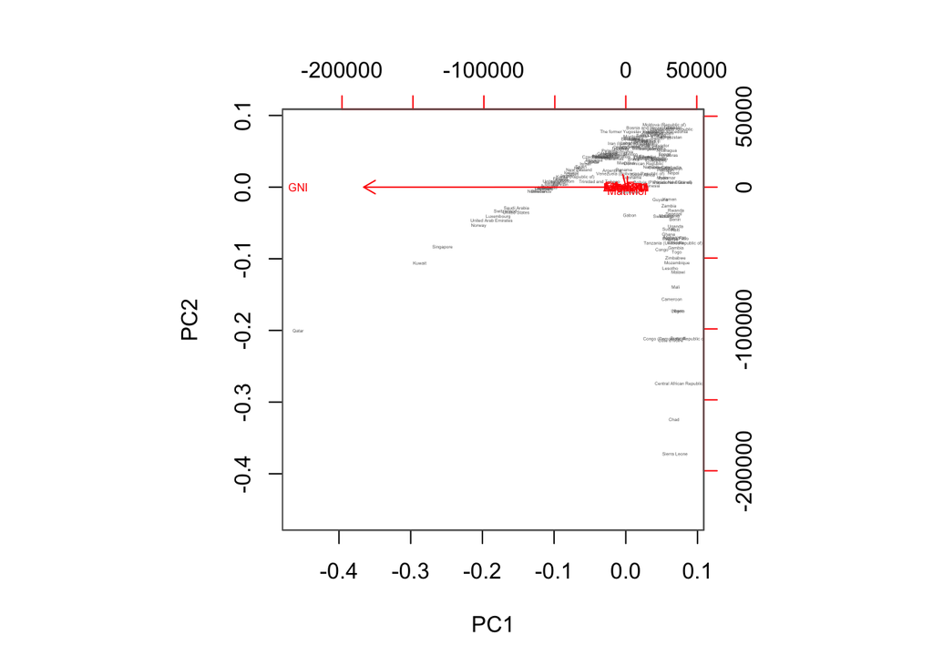

## **Standardize the variables in the human data and repeat the above analysis.**

```
##     Edu2.FM           Labo.FM           Edu.Exp           Life.Exp
##  Min.   :-2.8189   Min.   :-2.6247   Min.   :-2.7378   Min.   :-2.7188
##  1st Qu.:-0.5233   1st Qu.:-0.5484   1st Qu.:-0.6782   1st Qu.:-0.6425
##  Median : 0.3503   Median : 0.2316   Median : 0.1140   Median : 0.3056
##  Mean   : 0.0000   Mean   : 0.0000   Mean   : 0.0000   Mean   : 0.0000
##  3rd Qu.: 0.5958   3rd Qu.: 0.7350   3rd Qu.: 0.7126   3rd Qu.: 0.6717
##  Max.   : 2.6646   Max.   : 1.6632   Max.   : 2.4730   Max.   : 1.4218
##       GNI             Mat.Mor          Ado.Birth          Parli.F
##  Min.   :-0.9193   Min.   :-0.6992   Min.   :-1.1325   Min.   :-1.8203
##  1st Qu.:-0.7243   1st Qu.:-0.6496   1st Qu.:-0.8394   1st Qu.:-0.7409
##  Median :-0.3013   Median :-0.4726   Median :-0.3298   Median :-0.1403
##  Mean   : 0.0000   Mean   : 0.0000   Mean   : 0.0000   Mean   : 0.0000
##  3rd Qu.: 0.3712   3rd Qu.: 0.1932   3rd Qu.: 0.6030   3rd Qu.: 0.6127
##  Max.   : 5.6890   Max.   : 4.4899   Max.   : 3.8344   Max.   : 3.1850
```

```
## Importance of components:
##                           PC1    PC2     PC3     PC4     PC5     PC6
## Standard deviation     2.0708 1.1397 0.87505 0.77886 0.66196 0.53631
## Proportion of Variance 0.5361 0.1624 0.09571 0.07583 0.05477 0.03595
## Cumulative Proportion  0.5361 0.6984 0.79413 0.86996 0.92473 0.96069
##                            PC7     PC8
## Standard deviation     0.45900 0.32224
## Proportion of Variance 0.02634 0.01298
## Cumulative Proportion  0.98702 1.00000
```

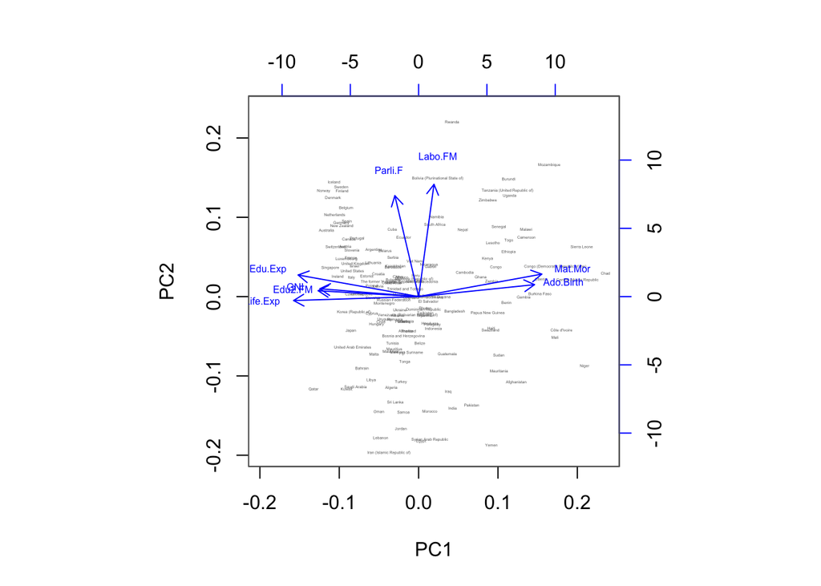

- Comparing the PCA plots of the non scaled and the scaled data, you can clearly see how the scaling works by making all the variables vary in the same range. This clearly helps to better observe the relation between the variables, otherwise as seen in the fisrt plot all the data will clump in one space position and make it impossible to identify the principal components that will help to classify the data.
- Focusing on the scaled data, you can now observe how the variables relate to each other, we can identifies 3 groups of variables that can be clearly separated by using the Principal components:
- Edu.Exp, Life.Exp, Edu2.FM, GNI
- Mat.Mor and Ado.Birth
- Labo.FM and Parli.F

## **Personal interpretations of the first two principal component dimensions based on the biplot drawn after PCA on the standardized human data.**

- By observing how the varibales distribute along the principal component axis it seems PC1 relates mainly with time related variables, Life expenctancy, Education expectancy, Mat.Mor and Ado.Birth.
- The PC2 relates more with the difference of genders in laboral life, education and politics. Since Edu2.FM lands in the zero values of PC2 one can assume there is an equilibrium in the amount of females and males with an higher education.

## **Load the tea dataset from the package Factominer.**

```r
# Load the tea dataset and packages FactoMineR
library(FactoMineR)
data("tea")
```

### **Explore the data briefly: look at the structure and the dimensions of the data and visualize it.**

```
## 'data.frame':    300 obs. of  36 variables:
##  $ breakfast       : Factor w/ 2 levels "breakfast","Not.breakfast": 1 1 2 2 1 2 1 2 1 1 ...
##  $ tea.time        : Factor w/ 2 levels "Not.tea time",..: 1 1 2 1 1 1 2 2 2 1 ...
##  $ evening         : Factor w/ 2 levels "evening","Not.evening": 2 2 1 2 1 2 2 1 2 1 ...
##  $ lunch           : Factor w/ 2 levels "lunch","Not.lunch": 2 2 2 2 2 2 2 2 2 2 ...
##  $ dinner          : Factor w/ 2 levels "dinner","Not.dinner": 2 2 1 1 2 1 2 2 2 2 ...
##  $ always          : Factor w/ 2 levels "always","Not.always": 2 2 2 2 1 2 2 2 2 2 ...
##  $ home            : Factor w/ 2 levels "home","Not.home": 1 1 1 1 1 1 1 1 1 1 ...
##  $ work            : Factor w/ 2 levels "Not.work","work": 1 1 2 1 1 1 1 1 1 1 ...
##  $ tearoom         : Factor w/ 2 levels "Not.tearoom",..: 1 1 1 1 1 1 1 1 1 2 ...
##  $ friends         : Factor w/ 2 levels "friends","Not.friends": 2 2 1 2 2 2 1 2 2 2 ...
##  $ resto           : Factor w/ 2 levels "Not.resto","resto": 1 1 2 1 1 1 1 1 1 1 ...
##  $ pub             : Factor w/ 2 levels "Not.pub","pub": 1 1 1 1 1 1 1 1 1 1 ...
##  $ Tea             : Factor w/ 3 levels "black","Earl Grey",..: 1 1 2 2 2 2 2 1 2 1 ...
##  $ How             : Factor w/ 4 levels "alone","lemon",..: 1 3 1 1 1 1 1 3 3 1 ...
```

[output cut: 22 more lines]

```
## [1] 300  36
```

- The data is formed by a total of 36 variables with 300 observations.
- Tea data contains information about when the enquired people drink tea, where they drink tea, how they drink the tea (either the format of the tea they use (“how”), or with some addictives (“How”)), what’s the price range of the consumed tea, the kind and purpose of the tea they drink, age and sex of the enquired people.

#### To better explode Tea data, I decided to start by focusing on the type of Tea (purpose of the Tea in this case) the enquired people consume.

```
##              escape.exoticism           spirituality        healthy
##  escape-exoticism    :142     Not.spirituality:206   healthy    :210
##  Not.escape-exoticism:158     spirituality    : 94   Not.healthy: 90
##          diuretic             friendliness            iron.absorption
##  diuretic    :174   friendliness    :242   iron absorption    : 31
##  Not.diuretic:126   Not.friendliness: 58   Not.iron absorption:269
##          feminine             sophisticated        slimming
##  feminine    :129   Not.sophisticated: 85   No.slimming:255
##  Not.feminine:171   sophisticated    :215   slimming   : 45
##         exciting          relaxing              effect.on.health
##  exciting   :116   No.relaxing:113   effect on health   : 66
##  No.exciting:184   relaxing   :187   No.effect on health:234
```

```
## 'data.frame':    300 obs. of  12 variables:
##  $ escape.exoticism: Factor w/ 2 levels "escape-exoticism",..: 2 1 2 1 1 2 2 2 2 2 ...
##  $ spirituality    : Factor w/ 2 levels "Not.spirituality",..: 1 1 1 2 2 1 1 1 1 1 ...
##  $ healthy         : Factor w/ 2 levels "healthy","Not.healthy": 1 1 1 1 2 1 1 1 2 1 ...
##  $ diuretic        : Factor w/ 2 levels "diuretic","Not.diuretic": 2 1 1 2 1 2 2 2 2 1 ...
##  $ friendliness    : Factor w/ 2 levels "friendliness",..: 2 2 1 2 1 2 2 1 2 1 ...
##  $ iron.absorption : Factor w/ 2 levels "iron absorption",..: 2 2 2 2 2 2 2 2 2 2 ...
##  $ feminine        : Factor w/ 2 levels "feminine","Not.feminine": 2 2 2 2 2 2 2 1 2 2 ...
##  $ sophisticated   : Factor w/ 2 levels "Not.sophisticated",..: 1 1 1 2 1 1 1 2 2 1 ...
##  $ slimming        : Factor w/ 2 levels "No.slimming",..: 1 1 1 1 1 1 1 1 1 1 ...
##  $ exciting        : Factor w/ 2 levels "exciting","No.exciting": 2 1 2 2 2 2 2 2 2 2 ...
##  $ relaxing        : Factor w/ 2 levels "No.relaxing",..: 1 1 2 2 2 2 2 2 2 2 ...
##  $ effect.on.health: Factor w/ 2 levels "effect on health",..: 2 2 2 2 2 2 2 2 2 2 ...
```

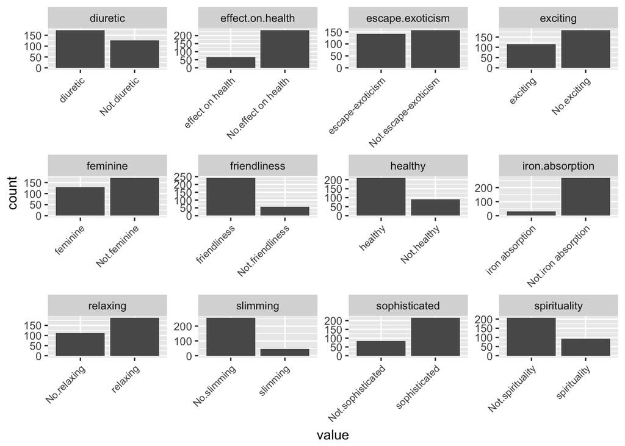

#### Since previous approach didn’t unreavel nothing that interesting, I decided to re- focus on the how, when and where people consume Tea together with gender differences of the enquired people.

```
##         Tea         How                      how           sugar
##  black    : 74   alone:195   tea bag           :170   No.sugar:155
##  Earl Grey:193   lemon: 33   tea bag+unpackaged: 94   sugar   :145
##  green    : 33   milk : 63   unpackaged        : 36
##                  other:  9
##
##
##                   where           lunch                 price     sex
##  chain store         :192   lunch    : 44   p_branded      : 95   F:178
##  chain store+tea shop: 78   Not.lunch:256   p_cheap        :  7   M:122
##  tea shop            : 30                   p_private label: 21
##                                             p_unknown      : 12
##                                             p_upscale      : 53
##                                             p_variable     :112
```

```
## 'data.frame':    300 obs. of  8 variables:
##  $ Tea  : Factor w/ 3 levels "black","Earl Grey",..: 1 1 2 2 2 2 2 1 2 1 ...
##  $ How  : Factor w/ 4 levels "alone","lemon",..: 1 3 1 1 1 1 1 3 3 1 ...
##  $ how  : Factor w/ 3 levels "tea bag","tea bag+unpackaged",..: 1 1 1 1 1 1 1 1 2 2 ...
##  $ sugar: Factor w/ 2 levels "No.sugar","sugar": 2 1 1 2 1 1 1 1 1 1 ...
##  $ where: Factor w/ 3 levels "chain store",..: 1 1 1 1 1 1 1 1 2 2 ...
##  $ lunch: Factor w/ 2 levels "lunch","Not.lunch": 2 2 2 2 2 2 2 2 2 2 ...
##  $ price: Factor w/ 6 levels "p_branded","p_cheap",..: 4 6 6 6 6 3 6 6 5 5 ...
##  $ sex  : Factor w/ 2 levels "F","M": 2 1 1 2 2 2 2 1 2 2 ...
```

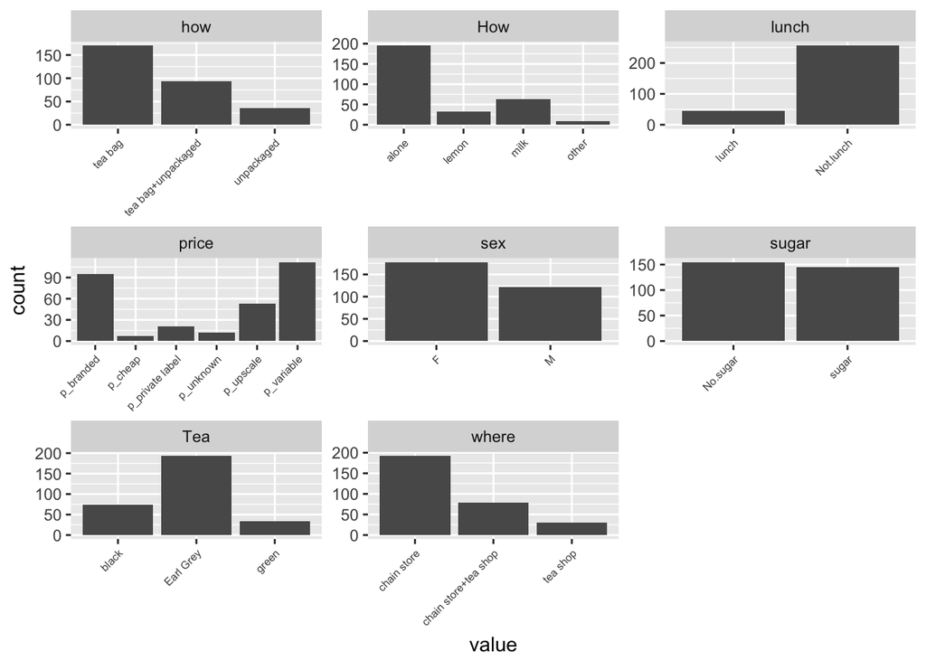

### **Then do Multiple Correspondence Analysis on the tea data (or to a certain columns of the data, it’s up to you).**

```r
# multiple correspondence analysis
mca <- MCA(tea_time, graph = FALSE)

# summary of the model
summary(mca)
```

```
##
## Call:
## MCA(X = tea_time, graph = FALSE)
##
##
## Eigenvalues
##                        Dim.1   Dim.2   Dim.3   Dim.4   Dim.5   Dim.6
## Variance               0.267   0.224   0.171   0.163   0.138   0.135
## % of var.             12.577  10.544   8.024   7.652   6.477   6.357
## Cumulative % of var.  12.577  23.121  31.145  38.797  45.274  51.631
##                        Dim.7   Dim.8   Dim.9  Dim.10  Dim.11  Dim.12
## Variance               0.132   0.124   0.119   0.113   0.103   0.100
## % of var.              6.222   5.826   5.609   5.310   4.849   4.695
## Cumulative % of var.  57.853  63.679  69.288  74.598  79.448  84.142
##                       Dim.13  Dim.14  Dim.15  Dim.16  Dim.17
## Variance               0.089   0.077   0.066   0.064   0.042
## % of var.              4.167   3.621   3.107   2.996   1.967
## Cumulative % of var.  88.310  91.930  95.037  98.033 100.000
##
## Individuals (the 10 first)
##                       Dim.1    ctr   cos2    Dim.2    ctr   cos2    Dim.3
## 1                  | -0.342  0.146  0.030 |  0.650  0.628  0.107 |  0.517
## 2                  | -0.206  0.053  0.029 | -0.067  0.007  0.003 | -0.259
## 3                  | -0.315  0.124  0.135 | -0.120  0.021  0.019 | -0.396
## 4                  | -0.331  0.137  0.129 |  0.147  0.032  0.026 |  0.285
## 5                  | -0.239  0.071  0.068 |  0.061  0.006  0.005 | -0.116
## 6                  | -0.395  0.195  0.068 |  0.437  0.283  0.083 | -0.009
## 7                  | -0.239  0.071  0.068 |  0.061  0.006  0.005 | -0.116
## 8                  | -0.206  0.053  0.029 | -0.067  0.007  0.003 | -0.259
## 9                  |  0.551  0.378  0.146 | -0.418  0.260  0.084 |  0.325
## 10                 |  0.775  0.749  0.303 | -0.336  0.168  0.057 | -0.186
##                       ctr   cos2
## 1                   0.523  0.068 |
## 2                   0.131  0.046 |
## 3                   0.307  0.213 |
## 4                   0.159  0.096 |
## 5                   0.026  0.016 |
## 6                   0.000  0.000 |
## 7                   0.026  0.016 |
## 8                   0.131  0.046 |
```

[output cut: 22 more lines]

```
## other                0.063  -4.326 |  -0.692   1.052   0.015  -2.103 |
## tea bag              0.163   6.989 |   0.002   0.000   0.000   0.034 |
## tea bag+unpackaged   0.447 -11.561 |   0.009   0.002   0.000   0.104 |
## unpackaged           0.114   5.845 |  -0.031   0.009   0.000  -0.200 |
##
## Categorical variables (eta2)
##                      Dim.1 Dim.2 Dim.3
## Tea                | 0.100 0.085 0.139 |
## How                | 0.049 0.073 0.365 |
## how                | 0.614 0.478 0.000 |
## sugar              | 0.037 0.027 0.439 |
## where              | 0.700 0.580 0.039 |
## lunch              | 0.000 0.093 0.038 |
## price              | 0.613 0.343 0.138 |
## sex                | 0.024 0.113 0.207 |
```

### **Drawing of the variable biplot of the previous analysis.**

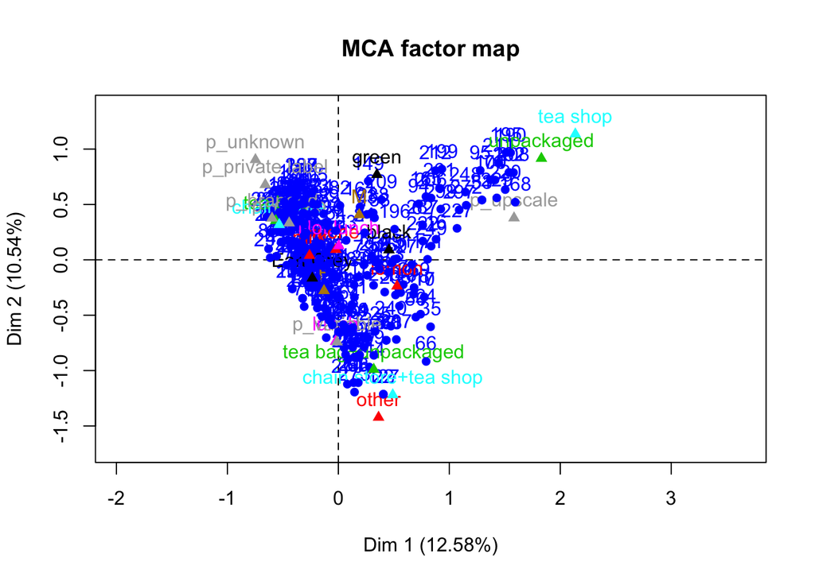

- The typical MCA bipolot shows the original classes of the discrete variables on the same “map”. This allows us to check the data distributions of the different variables, revealing the connections (correspondences) between different things that would be quite impossible to see from the corresponding cross table. The plot including all the data seems extremelly busy and difficult to verify the correlations between the variables
- The axis legends inlcude the name of the dimensions and their respective & of variance (calculated and show in the previous table)

### **Exploring other plotting options for better visualization of the variables relationships.**

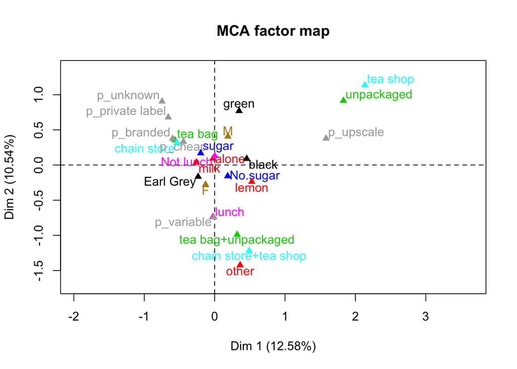